# Homework 1

Dylan Maddux

2024-09-11

### Exercise 0.32

**Renowned baseball statistician Bill James devised a model for predicting a team’s winning percentage. Dubbed the “Pythagorean Theorem of Baseball,” this model predicts a team’s winning percentage as (runs scored)^2 / ((runs scored)^2 + (runs against)^2) * 100**

**A.** Use the ‘Pythagorean theorem of Baseball’ model to predict the winning percentage for the Chicago Cubs, who scored 808 runs and allowed 556 runs in the 2016 season.

```r
808^2/(808^2+556^2) * 100
```

```
## [1] 67.86528
```

**B.** The Chicago Cubs actually won 103 games and lost 59 in the 2016 season. Determine the winning percentage and also determine the residual from the Pythagorean model (by taking the observed winning percentage minus the predicted winning percentage).

```r
103/(103+59) * 100
```

```
## [1] 63.58025
```

```r
63.58025-67.86528
```

```
## [1] -4.28503
```

**C.** Interpret what this residual value means for the 2016 Cubs.

The team did worse than expected according to the predictive model by a win percentage of 4.29 points.

**D.** Repeat parts (a–c) for the 2016 San Diego Padres, who scored 686 runs and allowed 770 runs, while winning 68 games and losing 94 games.

```r
686^2/(686^2+770^2) * 100
```

```
## [1] 44.24991
```

```r
68/(68+94) * 100
```

```
## [1] 41.97531
```

```r
41.97531-44.24991
```

```
## [1] -2.2746
```

**E.** Which team (Cubs or Padres) fell short of their Pythagorean expectations by more?

The Cubs fell short of their Pythagorean expectations by more.

**F.** Which team exceeded their Pythagorean expectations the most? Describe how this team’s winning percentage compares to what is predicted by their runs scored and runs allowed.

The Texas Rangers exceeded their Pythagorean expectation most with a residual of 8.12 percentage points: they were predicted to have a win rate of 50.53% and had an actual win rate of 58.64%.

**G.** Which team fell furthest below their Pythagorean expectations? Describe how this team’s winning percentage compares to what is predicted by their runs scored and runs allowed.

The Tampa Bay Rays fell furthest below their Pythagorean expectation most with a residual of -5.07 percentage points: they were predicted to have a win rate of 47.04% and had an actual win rate of 41.98%.

### Exercise 1.20

```r
#install.packages("Stat2Data")
library(Stat2Data)
library(ggplot2)
data("GrinnellHouses")
```

**The file GrinnellHouses contains data from 929 house sales in Grinnell, Iowa, between 2005 and into 2015. In this question we investigate the relationship of the list price of the home (what the seller asks for the home) to the final sale price. One would expect there to be a strong relationship. In most markets, including Grinnell during this period, list price almost always exceeds sale price.**

**A.** Make a scatterplot with ListPrice on the horizontal axis and SalePrice on the vertical axis. Comment on the pattern.

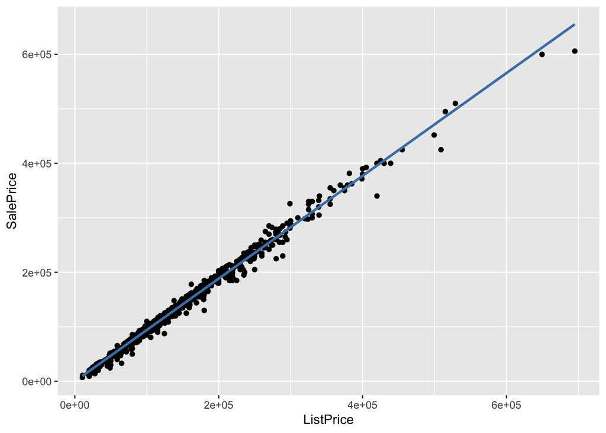

```r
ggplot(GrinnellHouses, aes(ListPrice, SalePrice)) +
  geom_point() +
  geom_smooth(method = "lm", se=F, color = "steelblue")
```

A strong linear trend appears between the two variables where Sale Price increases as List Price increases.

**B.** Find the least squares regression line for predicting sale price of a home based on list price of that home.

```r
model1 <- lm(SalePrice~ListPrice, GrinnellHouses)
model1
```

```
##
## Call:
## lm(formula = SalePrice ~ ListPrice, data = GrinnellHouses)
##
## Coefficients:
## (Intercept)    ListPrice
##   -144.8329       0.9431
```

SalePrice = 0.9431ListPrice - 144.8329

**C.** Interpret the value (not just the sign) of the slope of the fitted model in the context of this setting.

For every increase of 1000 dollars in the list price, the sale price increases by 943.1 dollars.

### Exercise 1.22

**Refer to the GrinnellHouses dataset.**

**A.** What sales price would the fitted model predict for a house that has a $99,500 listing price?

```r
(0.9431*99500) - 144.8329
```

```
## [1] 93693.62
```

$93,693.62

**B.** The house at 1317 Prince Street has a listing value of $99,500 and a sales price of $95,000. Find the residual for this data point.

```r
95000-93693.62
```

```
## [1] 1306.38
```

$1306.38

##### C. Does the linear regression model appear to be a good summary of the relationship between list price and sales price for houses in Grinnell, Iowa?

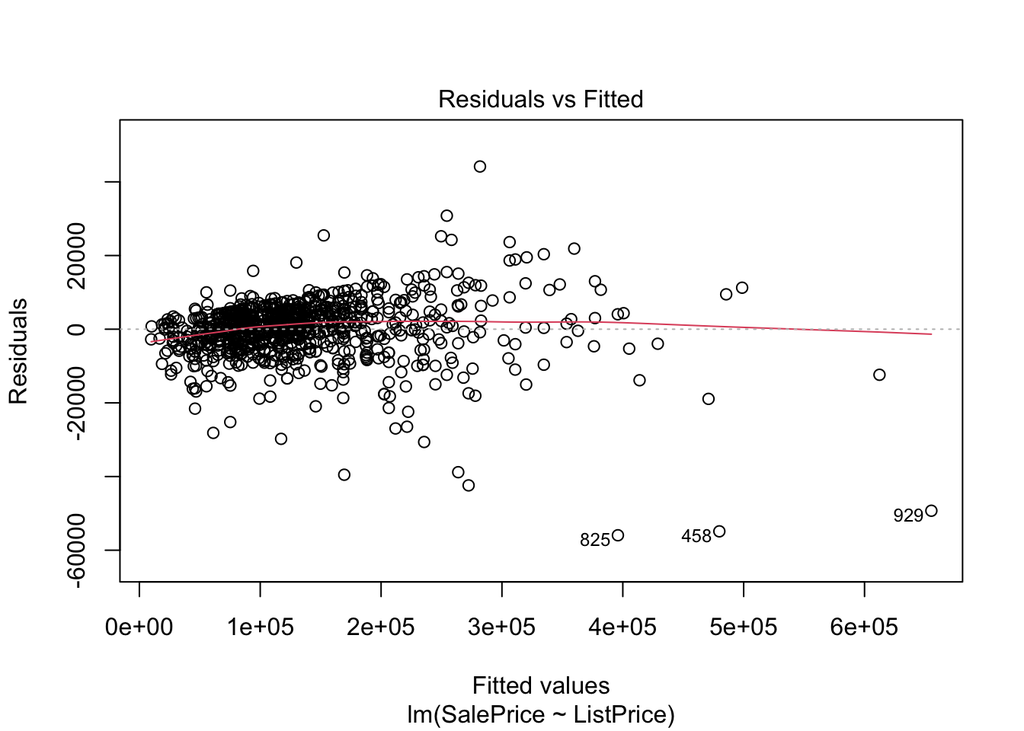

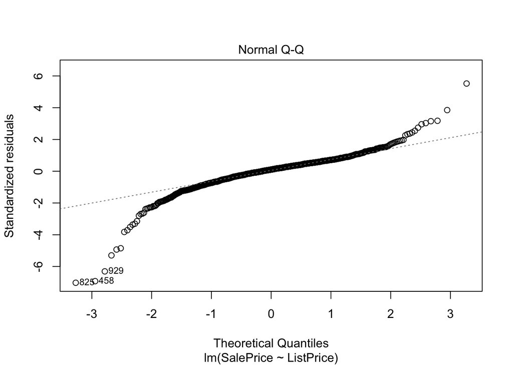

```r
plot(model1, 1:2)
```

### Exercise 1.34

```r
data("MathEnrollment")
```

**A.** Total enrollments in mathematics courses at a small liberal arts college were obtained for each semester from Fall 2001 to Spring 2012. Plot the mathematics enrollment for each semester against time. Is the trend over time roughly the same for both semesters? Explain.

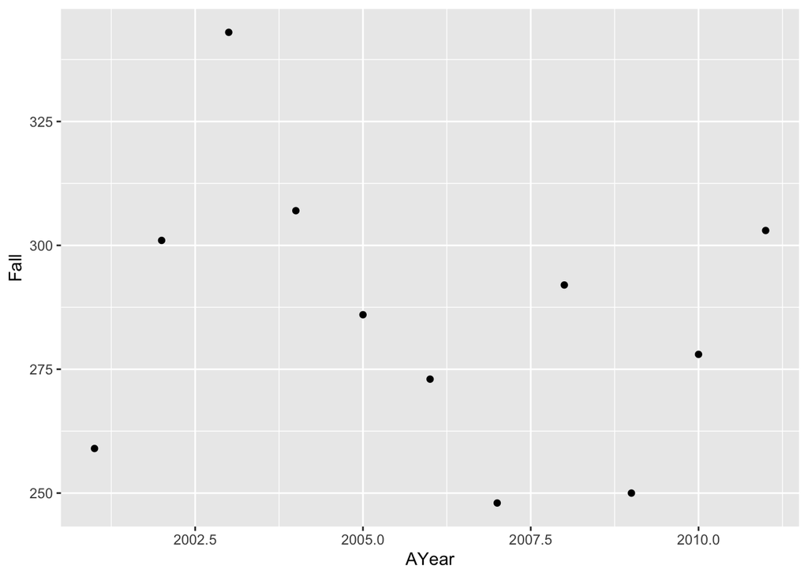

```r
ggplot(MathEnrollment, aes(AYear, Fall)) +
  geom_point()
```

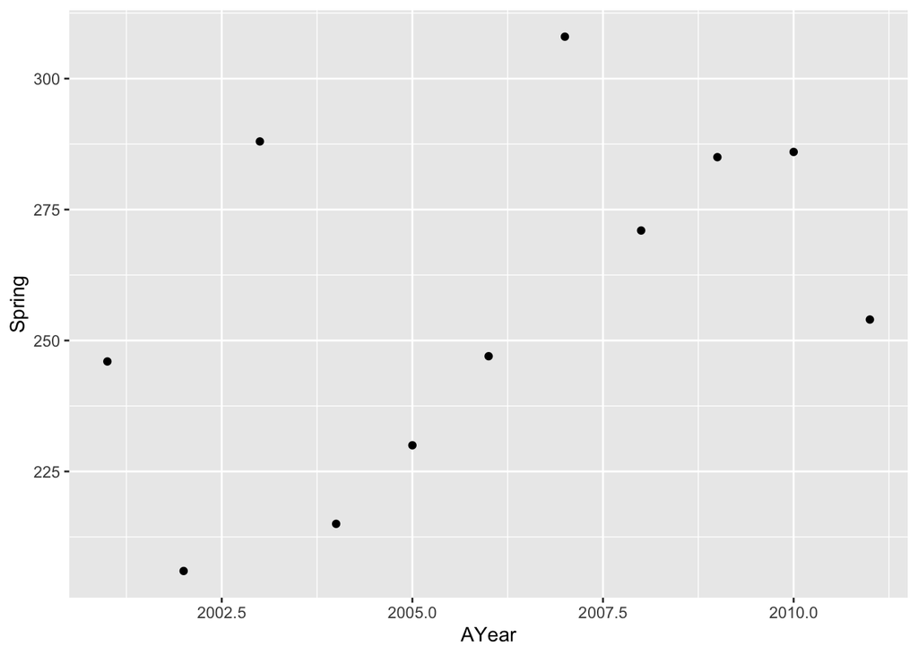

```r
ggplot(MathEnrollment, aes(AYear, Spring)) +
  geom_point()
```

**B.** A faculty member in the Mathematics Department believes that the fall enrollment provides a very good predictor of the spring enrollment. Do you agree?

```r
summary(lm(Spring~Fall, MathEnrollment))
```

```
##
## Call:
## lm(formula = Spring ~ Fall, data = MathEnrollment)
##
## Residuals:
##     Min      1Q  Median      3Q     Max
## -46.740 -24.050   1.913  20.674  48.978
##
## Coefficients:
##             Estimate Std. Error t value Pr(>|t|)
## (Intercept) 351.0585   106.4710   3.297  0.00927 **
## Fall         -0.3266     0.3713  -0.880  0.40195
## ---
## Signif. codes:  0 '***' 0.001 '**' 0.01 '*' 0.05 '.' 0.1 ' ' 1
##
## Residual standard error: 33.09 on 9 degrees of freedom
## Multiple R-squared:  0.07916,    Adjusted R-squared:  -0.02315
## F-statistic: 0.7737 on 1 and 9 DF,  p-value: 0.4019
```

I disagree since the linear model where Fall enrollment explains Spring enrollment has a high p-value of 0.402, indicating that the relationship between the variables is weak.

**C.** After examining a scatterplot with the least squares regression line for predicting spring enrollment from fall enrollment, two faculty members begin a debate about the possible influence of a particular point. Identify the point that the faculty members are concerned about.

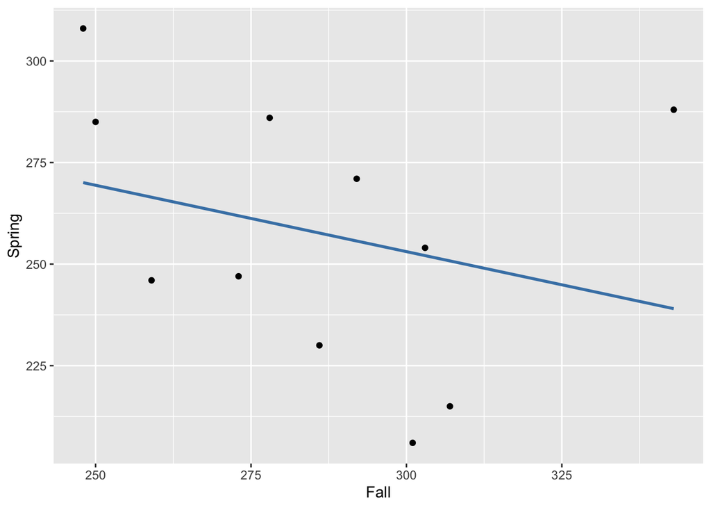

```r
ggplot(MathEnrollment, aes(Fall, Spring)) +
  geom_point() +
  geom_smooth(method = "lm", se=F, color = "steelblue")
```

The particular point is the 2003 data point where the Fall enrollment is 343 while the Spring enrollment is 288, since the point falls quite far away from the least squares regression line.

**D.** Fit the least squares line for predicting math enrollment in the spring from math enrollment in the fall, with and without the point you identified in part (c). Would you tag this point as influential? Explain.

```r
library(dplyr)
Enrollment2 <- MathEnrollment %>%
  filter(AYear != "2003")

summary(lm(Spring~Fall, MathEnrollment))
```

```
##
## Call:
## lm(formula = Spring ~ Fall, data = MathEnrollment)
##
## Residuals:
##     Min      1Q  Median      3Q     Max
## -46.740 -24.050   1.913  20.674  48.978
##
## Coefficients:
##             Estimate Std. Error t value Pr(>|t|)
## (Intercept) 351.0585   106.4710   3.297  0.00927 **
## Fall         -0.3266     0.3713  -0.880  0.40195
## ---
## Signif. codes:  0 '***' 0.001 '**' 0.01 '*' 0.05 '.' 0.1 ' ' 1
##
## Residual standard error: 33.09 on 9 degrees of freedom
## Multiple R-squared:  0.07916,    Adjusted R-squared:  -0.02315
## F-statistic: 0.7737 on 1 and 9 DF,  p-value: 0.4019
```

```r
summary(lm(Spring~Fall, Enrollment2))
```

```
##
## Call:
## lm(formula = Spring ~ Fall, data = Enrollment2)
##
## Residuals:
##     Min      1Q  Median      3Q     Max
## -30.500 -17.353  -6.058  22.711  29.418
##
## Coefficients:
##             Estimate Std. Error t value Pr(>|t|)
## (Intercept) 548.0094   106.7236   5.135 0.000891 ***
## Fall         -1.0483     0.3805  -2.755 0.024870 *
## ---
## Signif. codes:  0 '***' 0.001 '**' 0.01 '*' 0.05 '.' 0.1 ' ' 1
##
## Residual standard error: 24.94 on 8 degrees of freedom
## Multiple R-squared:  0.4868, Adjusted R-squared:  0.4227
## F-statistic: 7.589 on 1 and 8 DF,  p-value: 0.02487
```

Yes, I would tag this point as influential since the p-value from the model changed from 0.402 to 0.025 while the R^2 changed from 0.079 to 0.487 when the data point was removed.

### Exercise 1.44

```r
data("TextPrices")
```

**The price and number of pages of a random sample of 30 textbooks from Cal Poly was recorded to investigate the question of whether the number of pages can be used to predict price.**

**A.** Produce the relevant scatterplot to investigate the students’ question. Comment on what the scatterplot reveals about the question.

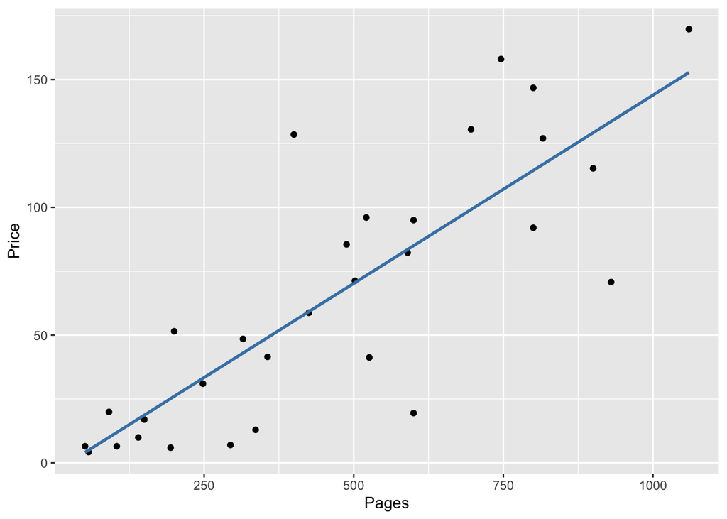

```r
ggplot(TextPrices, aes(Pages, Price)) +
  geom_point() +
  geom_smooth(method = "lm", se=F, color = "steelblue")
```

The scatterplot indicates that a higher number of pages correlates with a higher price.

**B.** Determine the equation of the regression line for predicting price from number of pages.

```r
model2 <- lm(Price~Pages, TextPrices)
summary(model2)
```

```
##
## Call:
## lm(formula = Price ~ Pages, data = TextPrices)
##
## Residuals:
##     Min      1Q  Median      3Q     Max
## -65.475 -12.324  -0.584  15.304  72.991
##
## Coefficients:
##             Estimate Std. Error t value Pr(>|t|)
## (Intercept) -3.42231   10.46374  -0.327    0.746
## Pages        0.14733    0.01925   7.653 2.45e-08 ***
## ---
## Signif. codes:  0 '***' 0.001 '**' 0.01 '*' 0.05 '.' 0.1 ' ' 1
##
## Residual standard error: 29.76 on 28 degrees of freedom
## Multiple R-squared:  0.6766, Adjusted R-squared:  0.665
## F-statistic: 58.57 on 1 and 28 DF,  p-value: 2.452e-08
```

Price = 0.147Pages - 3.422

**C.** Produce and examine relevant residual plots, and comment on what they reveal about whether the conditions for inference are met with these data.

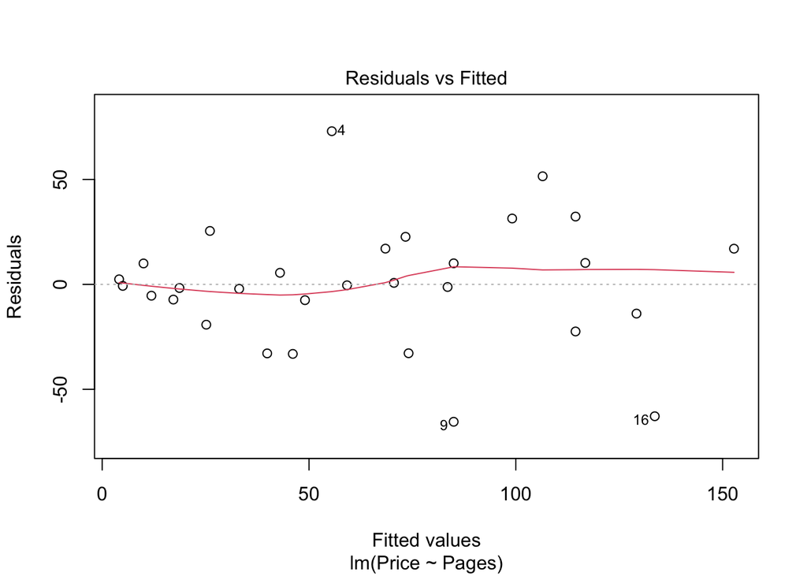

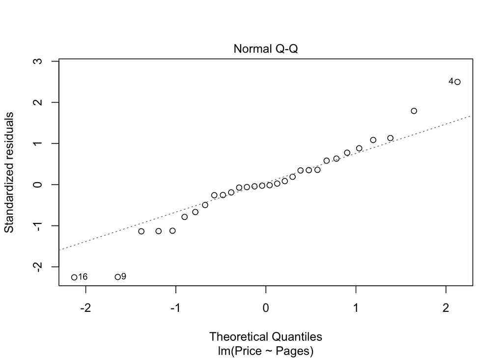

```r
plot(model2, 1:2)
```